# Maintain your brain, Days per Week of Resistance Training

## V20

- Secondary Outcome: Days resistance

These results exclude those participants who were eligible for fewer than 2 modules but who were randomised. This results in N=6104.

```r
# read in functions and data
source("functions.R")
myb_dat <- read.csv(paste0("../../Data/",params$data,".csv"))%>%
  mutate(group_type_id=as.factor(group_type_id),
         rc_trial_time=as.factor(rc_trial_time))

library(glmmTMB)
library(DHARMa)
```

Inference for differences in rc_trial_time trend by group_type_id for V20

## Data summary

A 5-number summary is presented for the values here as the data are highly skewed.

```r
p <- c(0, 0.25, 0.5, 0.75, 1.00)
p_names <- map_chr(p, ~paste0(.x*100))
p_funs <- map(p, ~partial(quantile, probs = .x, na.rm = TRUE)) %>%
  set_names(nm = p_names)

# Percentiles
myb_dat %>%
  group_by(rc_trial_time, group_type_id) %>%
  summarize_at(vars(V20), funs(!!!p_funs))
```

```
## # A tibble: 8 x 7
## # Groups:   rc_trial_time [4]
##   rc_trial_time group_type_id   `0`  `25`  `50`  `75` `100`
##   <fct>         <fct>         <dbl> <dbl> <dbl> <dbl> <dbl>
## 1 1             1                 0     0     0  1       14
## 2 1             2                 0     0     0  1       14
## 3 10            1                 0     0     0  1       14
## 4 10            2                 0     0     0  3       14
## 5 11            1                 0     0     0  1.75    14
## 6 11            2                 0     0     0  3       14
## 7 12            1                 0     0     0  1       14
## 8 12            2                 0     0     0  3       14
```

```r
# Means
myb_dat %>%
  group_by(.dots = lapply(params$predictors, as.symbol)) %>%
  summarize_at(.vars = params$response, .funs = list(Mean = mean, Sd = sd, N_obs = ~length(.)), na.rm=T)
```

```
## # A tibble: 8 x 5
## # Groups:   rc_trial_time [4]
##   rc_trial_time group_type_id  Mean    Sd N_obs
##   <fct>         <fct>         <dbl> <dbl> <int>
## 1 1             1             0.995  1.94  3053
## 2 1             2             1.00   2.03  3051
## 3 10            1             0.991  1.91  2128
## 4 10            2             1.80   2.58  1507
## 5 11            1             1.07   2.09  1906
## 6 11            2             1.82   2.77  1357
## 7 12            1             1.03   2.01  1961
## 8 12            2             1.75   2.72  1377
```

### Histograms

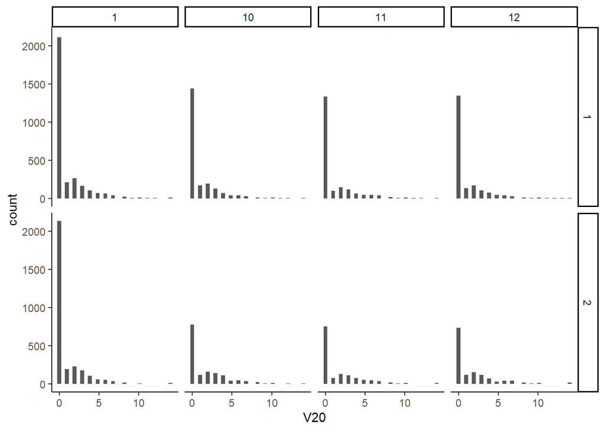

```r
myb_dat %>% ggplot(aes(x=V20)) + geom_histogram() + facet_grid(group_type_id~rc_trial_time) + theme_classic()
```

```r
if(!params$final){


  unadj_mod_int <- glmmTMB(V20 ~  rc_trial_time *group_type_id +
                         (1 | id_mask),
                       ziformula=~rc_trial_time *group_type_id,
                       data=myb_dat, family = poisson)

  unadj_mod_main <- glmmTMB(V20 ~  rc_trial_time +group_type_id +
                         (1 | id_mask),
                       ziformula=~rc_trial_time +group_type_id,
                       data=myb_dat, family = poisson)

  adj_mod_int <- glmmTMB(V20 ~  myb_age + myb_gender + cl_edu_yrs +
                           rcal_modules_sum +  adri_baseline +
                           rc_trial_time *group_type_id +
                         (1 | id_mask),
                       ziformula=~myb_age + myb_gender +
                         cl_edu_yrs + rcal_modules_sum +
                         adri_baseline +
                         rc_trial_time *group_type_id,
                       data=myb_dat, family = poisson)

  adj_mod_main <- glmmTMB(V20 ~  myb_age + myb_gender + cl_edu_yrs +
                           rcal_modules_sum +  adri_baseline +
                           rc_trial_time +group_type_id +
                         (1 | id_mask),
                       ziformula=~myb_age + myb_gender +
                         cl_edu_yrs + rcal_modules_sum +
                         adri_baseline +
                         rc_trial_time +group_type_id,
                       data=myb_dat, family = poisson)


fitted_mods = list(adj_mod = adj_mod_int,
              unadj_null = adj_mod_main,
              unadj_mod = unadj_mod_int,
              adj_null = unadj_mod_main)


  # save models
  save(fitted_mods,file = paste0("../../Results/baseline_sd/",params$response))

} else {
  load(file = paste0("../../Results/baseline_sd/",params$response))
}
```

```r
if(!params$final){
  # sim= simulateResiduals(fitted_mods$unadj_null, n = 5000)
  # resid = residuals(sim, quantileFunction = qnorm, outlierValues = c(-7,7))
  # scatter.smooth(resid~predict(fitted_mods$unadj_null, re.form = NA,type="response"),
  #                lpars =list(col = "red", lwd = 3, lty = 3))
  #
  # sim= simulateResiduals(fitted_mods$unadj_mod, n = 5000)
  # resid = residuals(sim, quantileFunction = qnorm, outlierValues = c(-7,7))
  # scatter.smooth(resid~predict(fitted_mods$unadj_mod, re.form = NA,type="response"),
  #                lpars =list(col = "red", lwd = 3, lty = 3))
  #
  # sim= simulateResiduals(fitted_mods$adj_null, n = 5000)
  # resid = residuals(sim, quantileFunction = qnorm, outlierValues = c(-7,7))
  # scatter.smooth(resid~predict(fitted_mods$adj_null, re.form = NA,type="response"),
  #                lpars =list(col = "red", lwd = 3, lty = 3))
  #
  # sim= simulateResiduals(fitted_mods$adj_mod, n = 5000)
  # resid = residuals(sim, quantileFunction = qnorm, outlierValues = c(-7,7))
  # scatter.smooth(resid~predict(fitted_mods$adj_mod, re.form = NA,type="response"),
  #                lpars =list(col = "red", lwd = 3, lty = 3))
  #


}
```

## Results

```r
if(!params$final){

  # calculate CI

  #unadjusted
  anova_call <- anova(fitted_mods$unadj_null,fitted_mods$unadj_mod)
  likrat <-  data.frame(Chisq = paste0(round(anova_call$Chisq[2],3),"(",
                                       anova_call$Df[2],")"),
                        pvalue = anova_call$`Pr(>Chisq)`[2])
  em <- emmeans(fitted_mods$unadj_mod,  ~ rc_trial_time * group_type_id , type = "response",
                at = list(rc_trial_time = plannedtimes) )
  cont <- contrast(em, interaction = c("consec", "consec"))
  CI <- confint(cont)
  Su <- summary(cont)
  coef <- as.data.frame(cont)$ratio
  confint <- CI[,c("asymp.LCL", "asymp.UCL")]
  zstat = round(Su$z.ratio,3)
  pz = ifelse (Su$p.value < 0.001, "<0.001",paste("= ",round(Su$p.value,3)))

  unadj_res = cbind(coef = coef, confint, zstat = zstat, pz = pz, likrat)

  #adjusted

  anova_call <- anova(fitted_mods$adj_null,fitted_mods$adj_mod)
  likrat <-  data.frame(Chisq = paste0(round(anova_call$Chisq[2],3),"(",
                                       anova_call$Df[2],")"),
                        pvalue = anova_call$`Pr(>Chisq)`[2])
  em <- emmeans(fitted_mods$adj_mod,  ~ rc_trial_time*group_type_id , type = "response",
                at = list(rc_trial_time = plannedtimes) )
  cont <- contrast(em, interaction = c("consec", "consec"))
  CI <- confint(cont)
  Su <- summary(cont)
  coef <- as.data.frame(cont)$ratio
  confint <- CI[,c("asymp.LCL", "asymp.UCL")]
  zstat = round(Su$z.ratio,3)
  pz = ifelse (Su$p.value < 0.001, "<0.001",paste("= ",round(Su$p.value,3)))
  adj_res = cbind(coef = coef, confint, zstat = zstat, pz = pz, likrat)


  # calculate CI
  res_tab <- rbind(adj_res,unadj_res) %>%
    as.data.frame() %>%
    remove_rownames %>%
    mutate(response = params$response,
           adjusted = c("No","Yes")) %>%
    transmute(response, adjusted,
              planned = coef, lower.CL = asymp.LCL, upper.CL = asymp.UCL,
              zstat = zstat, pz = pz,
              Chisq, p.value = pvalue)




  # save models
  write.csv(res_tab,file = paste0("../../Results/baseline_sd/",params$response,"_table.csv"), row.names = FALSE)



} else {
  res_tab <- read.csv(file = paste0("../../Results/baseline_sd/",params$response,"_table.csv"))


}

res <- res_tab %>%
  transmute(response,
            adjusted,
            base_3yr_ratio = round(planned,3),
            LCL = round(lower.CL,3),
            UCL = round(upper.CL,3),
            zstat,
            pz,
            Chisq,
            `p.value` = ifelse (`p.value` < 0.001, "<0.001",paste("= ",round(`p.value`,3)))
)

res
```

```
##   response adjusted base_3yr_ratio   LCL   UCL zstat       pz       Chisq
## 1      V20       No          1.167 1.057 1.289 3.047 =  0.002  485.88(27)
## 2      V20      Yes          1.166 1.043 1.302 2.702 =  0.007 216.631(21)
##   p.value
## 1  <0.001
## 2  <0.001
```

```r
evidence_unadj = ifelse(res_tab$p.value[1]<0.05, "evidence", "no evidence")
evidence_adj = ifelse(res_tab$p.value[2]<0.05, "evidence", "no evidence")
```

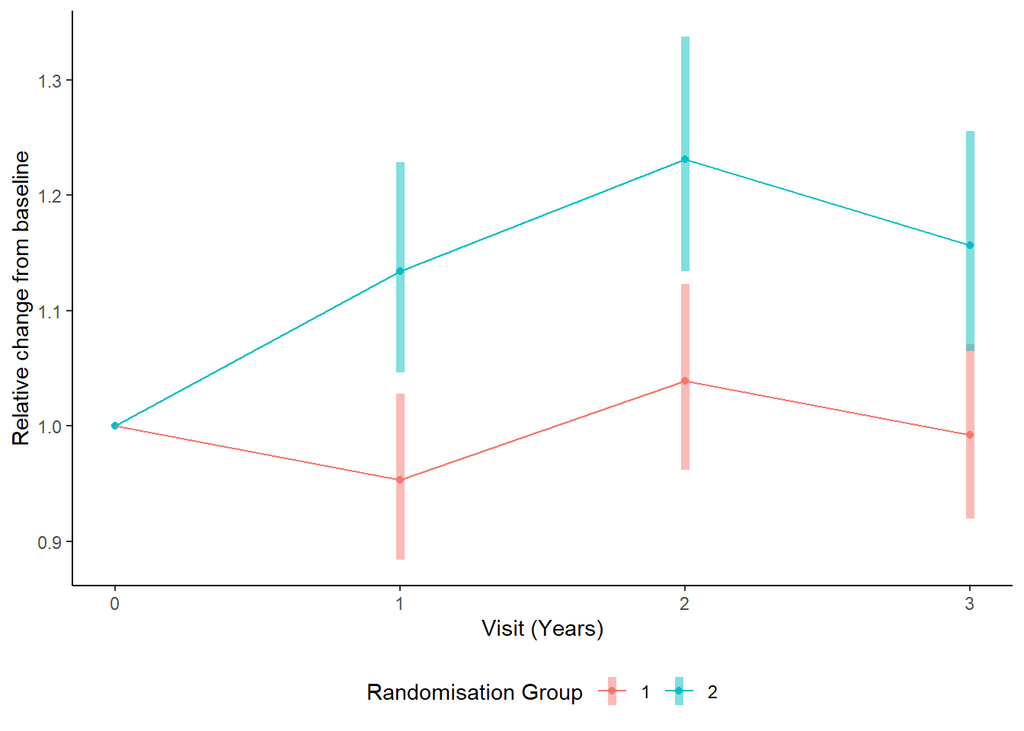

## Result

These data are counts with many zeros. As such, a normal distribution is not recommended. We used a zero inflated poisson distribution.

Covariates included in adjusted models:

- `myb_age`: Age at Baseline
- `myb_gender`: Reported gender
- `cl_edu_yrs`: Years of education
- `rcal_modules_sum`: Number of modules person was eligible for
- `adri_baseline`: ADRI at Baseline

A generalised linear mixed model (zero inflated poisson distribution) with a random effect for individual and fixed effects of time point, randomisation group and their interaction was run. An additional analysis including covariates of myb_age, myb_gender, cl_edu_yrs, rcal_modules_sum, adri_baseline was run. We report the relative change in days of resistance training within each group and the associated z statistic and p-value.

For group = 1, the unadjusted estimated relative change is 0.99 from baseline to 3 years (95%CI 0.92 - 1.07), for group 2, the estimated relative change is 1.16 from baseline to 3 years (95%CI 1.06 - 1.26). The unadjusted ratio between randomisation groups of relative change from baseline to three year follow up was 1.167 ( 95%CI: 1.057- 1.289, Z=3.047,p= 0.002 ).

Analysis by Nancy Briggs and Gordana Popovic on 2024-02-14